# Pathway Analysis for metabolomics

## Mummichog change of approach

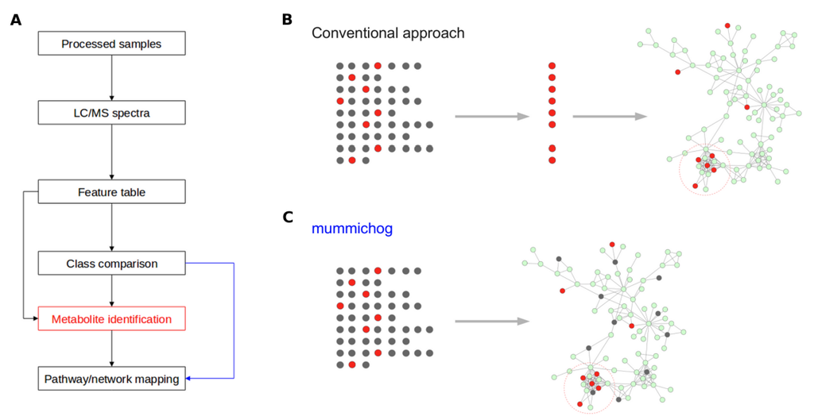

Mummichog redefines the work flow of untargeted metabolomics

## A mummichog pseudo-example

- Imagine a dataset with 1000 peaks where the top (most significant) 100 peaks are retained.
- Even if their identities are not known, many may still map to overlapping sets of candidate metabolites.
- If a relevant biological pathway is truly perturbed, those candidates will tend to accumulate in that pathway more strongly than expected by chance.
- The interpretation is therefore probabilistic and pathway-centered rather than metabolite-centered.

## Mummichog: limitations

- Because multiple candidate metabolites can be assigned to each feature, the method may generate false positives.
- Its performance depends on the quality and coverage of the pathway database and on the quality of the mass matching step.
- The output is extremely useful for hypothesis generation, but it should not be confused with definitive metabolite identification.

## Comparison of the four

| Method | Family | Input | Strength | Limitation |
| --- | --- | --- | --- | --- |
| ORA | Set-based | Significant metabolite list | Simple, intuitive and easy to communicate | Depends on an arbitrary threshold |
| GSEA | Functional class scoring | Ranked metabolite list | Detects coordinated changes without thresholding | Depends on ranking and annotation |
| Mummichog | ORA-like untargeted data | Untargeted peak list | Works before full metabolite identification | Can increase false positives |
| FELLA | Topology-based | Annotated metabolites | Incorporates network context and indirect relationships | Requires annotation and more computation |

## PWA Methods summary

- There is no universally best method for pathway analysis in metabolomics.
- ORA is simple and often useful as a baseline.
- GSEA is attractive when one expects coordinated moderate changes across a pathway.
- FELLA adds network context and can be very informative when reliable annotation is available.
- Mummichog is especially valuable for untargeted LC-MS data because it allows pathway-level interpretation before complete identification.
- In practice, the best choice depends on the study design, the annotation level, the biological question, and the balance one wishes to strike between interpretability, sensitivity and specificity (Khatri, Sirota, and Butte 2012; Karnovsky and Li 2020; Lu, Pang, and Xia 2022).

# Limitations and Recommendations

## Some limitations

- Incomplete Pathway Databases
- Metabolite Misidentification
- Chemical Bias of Assays
- Background Set Selection
- Selection of Compounds of Interest
- Multiple testing issues

[figure not shown]

# Pathway Analysis Tools

## Pathway Analysis Tools

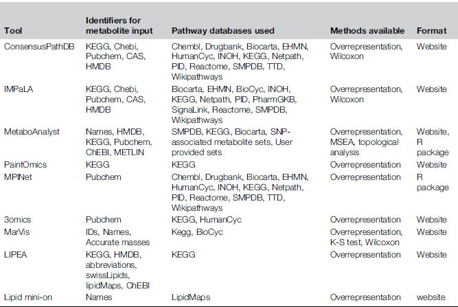

Common pathway analysis tools for metabolomics data.

## A comparison of tools

[figure not shown]

[Evaluation and comparison of bioinformatic tools for the enrichment analysis of metabolomics data](https://bmcbioinformatics.biomedcentral.com/articles/10.1186/s12859-017-2006-0)

## The space of tools (in 2017)

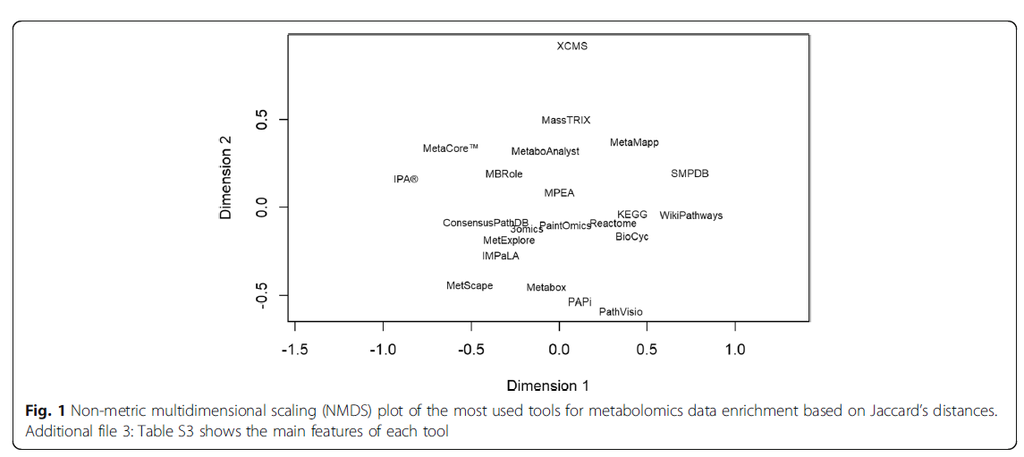

## Summary

- Pathway Analysis is a useful approach to help gain biological understanding from omics-based studies.
- There are many ways, many methods, many tools
- Guide the choice by a combination of *meaning*, *availability*, *ease of use* and *usefulness*.
- Usually obtained from a good understanding of what it does and ow it is done.
- Different methods may yield different results.  
  Worth checking!

## Acknowledgements

# APPENDICES

# Multiple testing problem and adjustments

## Multiple testing

- Whatever approach we use for pathway Analysis there is a common characteristic: *Every test is applied for every feature set in a long collection of sets*
- This leads to a *multiple testing problem*: the Type I error probability of falsely rejecting the null hypothesis increases with the number of tests.
- In order to avoid an artificial inflation of *False positive discoveries* some adjustments are recommended.

## Hypothesis Tests Decision Table

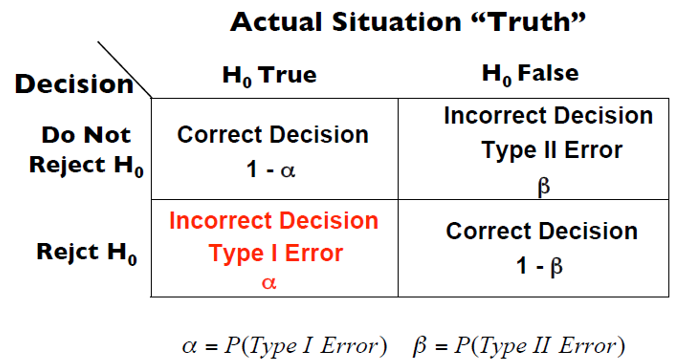

In a test with a null and an alternative hypothesis there are 2 possible right decisions and two possible incorrect ones (Type I and Type II errors)

## Why Multiple testing matters

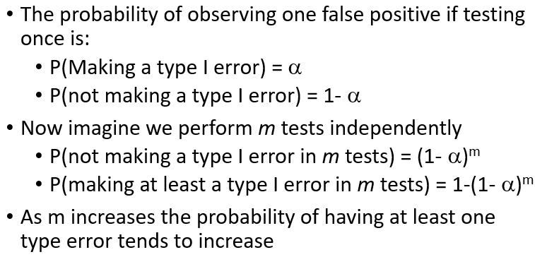

## TYpe I error not useful here

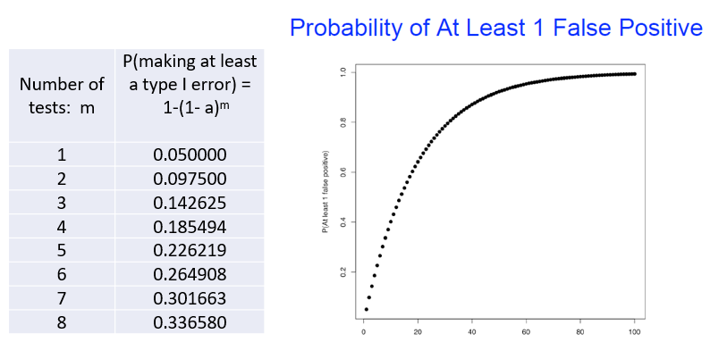

## How to deal with this issue?

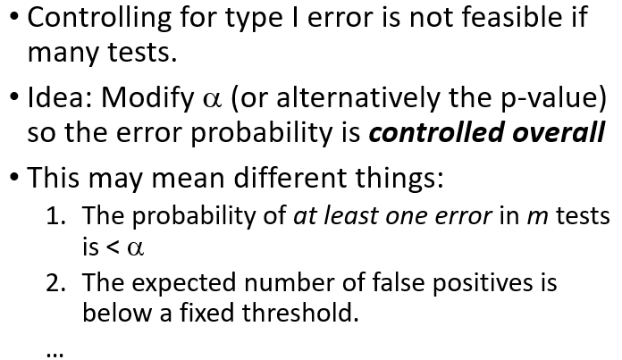

## *Family Wise Error Rate*

- Let $M$ be the number of annotations tested.
- Given p-value, $p$ compute $p_{adj}=p\times M$, or
- Given significance level $\alpha$ compute $\alpha_{adj}=\alpha/M$.
- The adjusted P-value, $p_{adj}$ is greater than or equal to the probability that **one or more** of the observed enrichments are due to random draws.
- This adjustment is said to *controling for the Family-Wise Error Rate* (FWER).
- Bonferroni method controls FWER.

## Bonferroni Caveats

- This adjustment is very stringent and can “wash away” real enrichments leading to false negatives,
- Often one is willing to accept a less stringent condition, that is accepting some false positives to avoid too many false negatives.
- This is may be done using the “*false discovery rate*” (FDR), which leads to a gentler correction when there are real enrichments.

## False Discovery Rate

- FDR is the expected proportion of “False Positives” that is of the observed enrichments due to chance.
- Less restrictive than Bonferroni adjustment which is a bound on the probability that **any one** of the observed enrichments could be due to random chance.
- Typically, FDR adjustments are calculated using the Benjamini-Hochberg procedure.
- FDR threshold is often called the “q-value”

## An example

|  | raw | Bonferroni | FDR |
| --- | --- | --- | --- |
| Quinolinate | 0.000119 | 0.007484 | 0.004261 |
| Valine | 0.000164 | 0.010333 | 0.004261 |
| N,N-Dimethylglycine | 0.000203 | 0.012784 | 0.004261 |
| Leucine | 0.000378 | 0.023786 | 0.004313 |
| Dimethylamine | 0.000417 | 0.026265 | 0.004313 |
| Pyroglutamate | 0.000455 | 0.028645 | 0.004313 |
| Creatinine | 0.000479 | 0.030191 | 0.004313 |
| Glutamine | 0.001000 | 0.062999 | 0.007791 |
| Alanine | 0.001113 | 0.070120 | 0.007791 |
| 3-Hydroxybutyrate | 0.001396 | 0.087925 | 0.008793 |
| Tryptophan | 0.001880 | 0.118456 | 0.010769 |
| myo-Inositol | 0.002109 | 0.132897 | 0.011075 |
| Betaine | 0.002901 | 0.182737 | 0.013787 |
| Threonine | 0.003182 | 0.200497 | 0.013787 |
| Methylamine | 0.003565 | 0.224596 | 0.013787 |
| Serine | 0.003593 | 0.226386 | 0.013787 |
| cis-Aconitate | 0.003720 | 0.234386 | 0.013787 |
| Fucose | 0.005700 | 0.359082 | 0.019386 |
| Acetate | 0.005919 | 0.372877 | 0.019386 |
| 2-Hydroxyisobutyrate | 0.006154 | 0.387715 | 0.019386 |
| Asparagine | 0.006752 | 0.425385 | 0.020256 |
| 3-Indoxylsulfate | 0.008587 | 0.541004 | 0.024291 |
| 3-Hydroxyisovalerate | 0.008868 | 0.558695 | 0.024291 |
| Histidine | 0.010569 | 0.665852 | 0.026902 |
| Tyrosine | 0.011022 | 0.694406 | 0.026902 |
| Succinate | 0.011102 | 0.699444 | 0.026902 |
| Citrate | 0.012393 | 0.780760 | 0.027913 |
| Trigonelline | 0.012406 | 0.781577 | 0.027913 |
| Formate | 0.016883 | 1.000000 | 0.036677 |
| Pyruvate | 0.019102 | 1.000000 | 0.040115 |
| tau-Methylhistidine | 0.021644 | 1.000000 | 0.042989 |
| Hippurate | 0.022506 | 1.000000 | 0.042989 |
| trans-Aconitate | 0.022518 | 1.000000 | 0.042989 |
| Ethanolamine | 0.025818 | 1.000000 | 0.047839 |
| Glycine | 0.027327 | 1.000000 | 0.048003 |
| Adipate | 0.027430 | 1.000000 | 0.048003 |
| 2-Aminobutyrate | 0.029336 | 1.000000 | 0.049950 |
| Taurine | 0.031458 | 1.000000 | 0.052154 |
| Glucose | 0.032393 | 1.000000 | 0.052328 |
| Trimethylamine N-oxide | 0.040539 | 1.000000 | 0.063849 |
| 1,6-Anhydro-beta-D-glucose | 0.049768 | 1.000000 | 0.076473 |
| Creatine | 0.051445 | 1.000000 | 0.077168 |
| Glycolate | 0.055152 | 1.000000 | 0.080804 |
| Carnitine | 0.061398 | 1.000000 | 0.087911 |
| O-Acetylcarnitine | 0.063216 | 1.000000 | 0.088502 |
| Fumarate | 0.073731 | 1.000000 | 0.100980 |
| Sucrose | 0.117577 | 1.000000 | 0.157603 |
| Lactate | 0.120919 | 1.000000 | 0.158706 |
| Guanidoacetate | 0.136587 | 1.000000 | 0.175456 |
| pi-Methylhistidine | 0.139251 | 1.000000 | 0.175456 |
| 3-Aminoisobutyrate | 0.175845 | 1.000000 | 0.217220 |
| Xylose | 0.213149 | 1.000000 | 0.258238 |
| 2-Oxoglutarate | 0.222700 | 1.000000 | 0.261157 |
| Isoleucine | 0.223849 | 1.000000 | 0.261157 |
| Hypoxanthine | 0.254889 | 1.000000 | 0.291964 |
| Methylguanidine | 0.274438 | 1.000000 | 0.308742 |
| Lysine | 0.279636 | 1.000000 | 0.309071 |
| Acetone | 0.380849 | 1.000000 | 0.413680 |
| Tartrate | 0.444636 | 1.000000 | 0.474780 |
| 4-Hydroxyphenylacetate | 0.479904 | 1.000000 | 0.503899 |
| Pantothenate | 0.533904 | 1.000000 | 0.551409 |
| Uracil | 0.545005 | 1.000000 | 0.553796 |
| 1-Methylnicotinamide | 0.934023 | 1.000000 | 0.934023 |

## References

Karnovsky, Alla, and Shuzhao Li. 2020. “Pathway Analysis for Targeted and Untargeted Metabolomics.” *Methods in Molecular Biology* 2104: 387–400. https://doi.org/10.1007/978-1-0716-0239-3_19/FIGURES/3.

Khatri, Purvesh, Marina Sirota, and Atul J. Butte. 2012. “Ten Years of Pathway Analysis: Current Approaches and Outstanding Challenges.” *PLoS Computational Biology* 8. https://doi.org/10.1371/JOURNAL.PCBI.1002375.

Li, Shuzhao, Youngjoon Park, Suresh Duraisingham, Felix H. Strobel, Nazia Khan, Qahtan A. Soltow, Dean P. Jones, and Bali Pulendran. 2013. “Predicting Network Activity from High Throughput Metabolomics.” *PLoS Computational Biology* 9 (7): e1003123. https://doi.org/10.1371/journal.pcbi.1003123.

Lu, Yao, Zhiqiang Pang, and Jianguo Xia. 2022. “Comprehensive Investigation of Pathway Enrichment Methods for Functional Interpretation of LC–MS Global Metabolomics Data.” *Briefings in Bioinformatics* 24 (1): bbac553. https://doi.org/10.1093/bib/bbac553.

Picart-Armada, Sergi, Francesc Fernández-Albert, Maria Vinaixa, Oscar Yanes, and Alexandre Perera-Lluna. 2018. “FELLA: An r Package to Enrich Metabolomics Data.” *BMC Bioinformatics* 19 (1): 538. https://doi.org/10.1186/s12859-018-2487-5.

Subramanian, Aravind, Pablo Tamayo, Vamsi K. Mootha, Sayan Mukherjee, Benjamin L. Ebert, Michael A. Gillette, Amanda Paulovich, et al. 2005. “Gene Set Enrichment Analysis: A Knowledge-Based Approach for Interpreting Genome-Wide Expression Profiles.” *Proceedings of the National Academy of Sciences of the United States of America* 102 (October): 15545–50. https://doi.org/10.1073/PNAS.0506580102.

Xia, Jianguo, David S. Wishart, and Alfonso Valencia. 2011. “MetPA: A Web-Based Metabolomics Tool for Pathway Analysis and Visualization.” *Bioinformatics* 27: 2342–44. https://doi.org/10.1093/BIOINFORMATICS/BTQ418.